# pk_sample_size

Chao Cheng

2022-09-23

```r
library(tidyverse)
```

## 0.1 背景介绍

假设个体PK参数独立同分布服从log-normal分布，那么 **对样本取对数** 后，有

$$x_1, \cdots, x_n \overset{i.i.d.}{\sim}
N\left(\mu, \sigma^2\right)$$

那么显然有

$$\frac{\bar{x} - \mu}{\sqrt{S^2 / n}}\sim
t_{n - 1}$$

其中$\bar{x}$是样本均值，$S^2$是样本标准差，且

$$\frac{(n - 1)S^2}{\sigma^2}\sim\chi^2_{n
- 1}$$
另外，在 **原始数据尺度** 上的CV满足(由log-normal性质得到)

$$CV = \sqrt{\mathrm{exp}(\sigma^2) -
1}$$

### 0.1.1 构造 $(1 - \alpha)$ CI

首先我们可以构造$\bar{x} - \mu$的CI。由于此时的数据进行了对数变换，那么实际上在原尺度上就是pk参数 over geometric mean的区间。

$$P\left(
-t_{1 - \alpha / 2, n - 1} * \sqrt{S^2 / n} \leq \bar{x} - \mu \leq t_{1
- \alpha / 2, n - 1} * \sqrt{S^2 / n}
\right) = 1 - \alpha$$

此时的区间（在对数变换后的尺度上） **半** 宽度为

$$t_{1 - \alpha / 2, n - 1} * \sqrt{S^2 /
n}$$

*注意：* 截图中的(0.7, 1.43)的区间，实际上在对数变换后对应着(-0.35, 0.35)，区间半宽度0.35。

### 0.1.2 符合半宽度要求的chance

利用$\frac{(n - 1)S^2}{\sigma^2}\sim\chi^2_{n - 1}$我们可以得到区间半宽度符合（小于等于）某一给定的界值（如0.35）的概率为

$$\begin{aligned}
&P\left(t_{1 - \alpha / 2, n - 1} * \sqrt{S^2 / n} \leq
0.35\right) \\
=& P\left(\frac{(n - 1)S^2}{\sigma^2}\cdot \frac{t_{1 - \alpha / 2,
n - 1}^2}{n} \leq 0.35^2 \cdot \frac{n - 1}{\sigma^2}\right) \\
=& P\left(\chi^2_{n - 1} \leq \frac{0.35^2\cdot n(n - 1)}{t_{1 -
\alpha / 2, n - 1}^2\sigma^2}\right)
\end{aligned}$$

即一个自由度为$n-1$的卡方分布随机变量，取值小于$\frac{0.35^2\cdot n(n - 1)}{t_{1 - \alpha / 2, n - 1}^2\sigma^2}$的概率。

### 0.1.3 截图结果的验证

```r
a <- 0.1
cv <- 0.4
n <- 6
width_limit <- 0.35

# Get_Chance() 定义见后文
chance <- Get_Chance(n = n, a = a, cv = cv, width_limit = width_limit)
print(paste0("Change is : ", chance))
```

```
## [1] "Change is : 0.703209124656924"
```

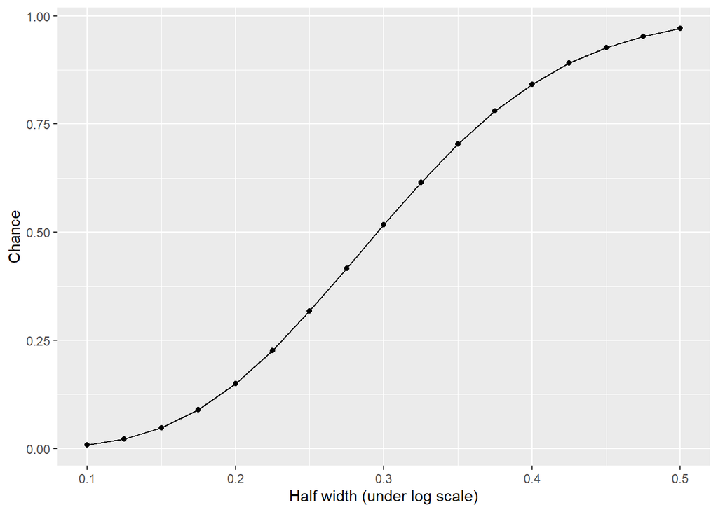

## 0.2 Case1: 给定CV，Chance和alpha后的CI

在给定Chance，CV, alpha和 **样本量** 后，实际上我们就可以得到（对数变换后）的CI半宽度，从而得到原始尺度上的区间

```r
Get_Width <- function(n = 6, a = 0.1, cv = 0.15, chance = 0.7){
    # 注意：本函数计算的是log变换后尺度上的区间半宽度
    sigma2 <- log(1 + cv ^ 2)
    t_cut <- qt(1 - a / 2, df = n - 1)
    chisq_cut <- qchisq(chance, df = n - 1)
    width <- sqrt(chisq_cut * t_cut ^ 2 * sigma2 / n / (n - 1))
    return(width)
}
```

```r
cv_vec <- seq(from = 0.15, to = 0.4, by = 0.05)
chance_vec <- c(0.7, 0.8)
n_vec <- 6
a <- 0.1
res <- expand.grid(cv = cv_vec, chance = chance_vec, n = n_vec, a = a)
for(i in seq(nrow(res))){
    tmp <- Get_Width(n = res$n[i], a = res$a[i],
                     cv = res$cv[i], chance = res$chance[i])
    res$lower[i] <- exp(-tmp)
    res$upper[i] <- exp(tmp)
    res$width_log[i] <- abs(tmp)    # log变换尺度上的区间半宽度
}
knitr::kable(res)
```

| cv | chance | n | a | lower | upper | width_log |
| --- | --- | --- | --- | --- | --- | --- |
| 0.15 | 0.7 | 6 | 0.1 | 0.8735917 | 1.144699 | 0.1351421 |
| 0.20 | 0.7 | 6 | 0.1 | 0.8357525 | 1.196527 | 0.1794228 |
| 0.25 | 0.7 | 6 | 0.1 | 0.8000575 | 1.249910 | 0.2230716 |
| 0.30 | 0.7 | 6 | 0.1 | 0.7664693 | 1.304684 | 0.2659606 |
| 0.35 | 0.7 | 6 | 0.1 | 0.7349311 | 1.360672 | 0.3079786 |
| 0.40 | 0.7 | 6 | 0.1 | 0.7053701 | 1.417695 | 0.3490327 |
| 0.15 | 0.8 | 6 | 0.1 | 0.8622911 | 1.159701 | 0.1481624 |
| 0.20 | 0.8 | 6 | 0.1 | 0.8214294 | 1.217390 | 0.1967093 |
| 0.25 | 0.8 | 6 | 0.1 | 0.7830463 | 1.277064 | 0.2445635 |
| 0.30 | 0.8 | 6 | 0.1 | 0.7470789 | 1.338547 | 0.2915845 |
| 0.35 | 0.8 | 6 | 0.1 | 0.7134444 | 1.401651 | 0.3376507 |
| 0.40 | 0.8 | 6 | 0.1 | 0.6820446 | 1.466180 | 0.3826602 |

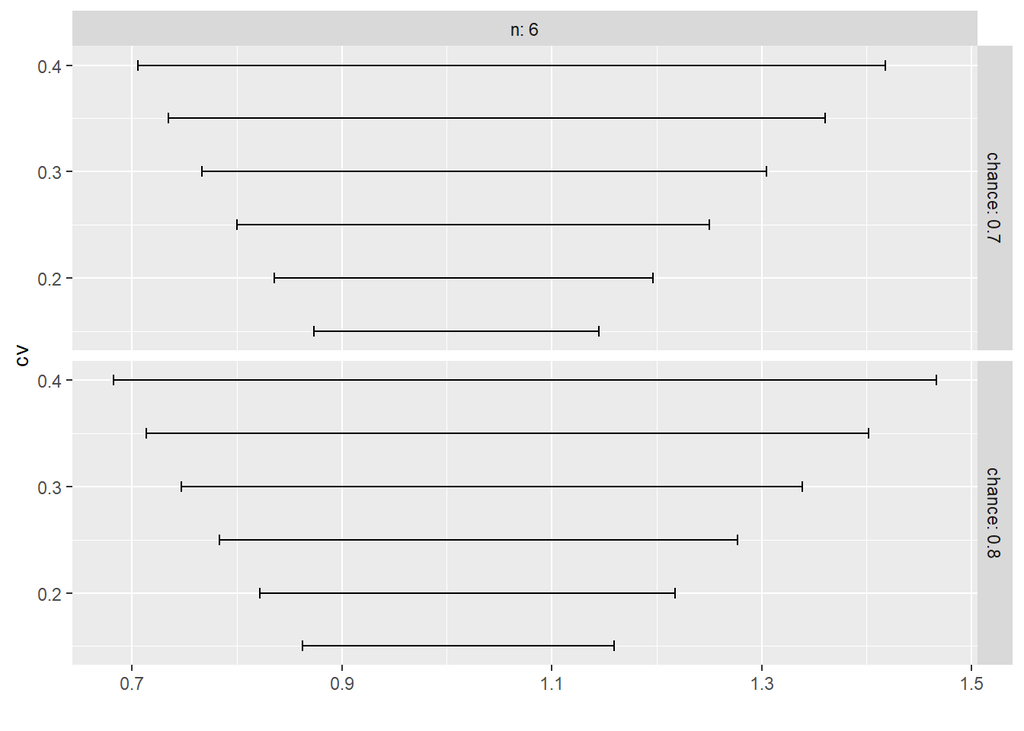

## 0.3 Case2: 给定CV，alpha和CI后的chance

在给定CV，alpha，CI(实际上是半宽度的要求）和 **样本量** 后，我们可以得到相应的CI符合半宽度要求的chance

```r
Get_Chance <- function(n = 6, a = 0.1, cv = 0.15, width_limit = 0.35){
    # 注意：这里的`width_limit`是对数变换后的CI区间的**半宽度**要求
    sigma2 <- log(1 + cv ^ 2)
    t_cut <- qt(1 - a / 2, df = n - 1)
    chisq_cut <- width_limit ^ 2 * n * (n - 1) / t_cut ^ 2 / sigma2
    chance <- pchisq(chisq_cut, df = n - 1)
    return(chance)
}
```

```r
cv_vec <- seq(from = 0.15, to = 0.4, by = 0.05)
width_limit <- 0.3576744    # 原始尺度上的(0.7, 1.43)对应对数尺度上的0.35的半宽度
n_vec <- 6
a <- 0.1

res <- expand.grid(cv = cv_vec, n = n_vec, width_limit = width_limit, a = a)
for(i in seq(nrow(res))){
    tmp <- Get_Chance(n = res$n[i], a = res$a[i],
                      cv = res$cv[i], width_limit = res$width_limit[i])
    res$chance[i] <- tmp
}
knitr::kable(res[, c("cv", "n", "chance")])
```

| cv | n | chance |
| --- | --- | --- |
| 0.15 | 6 | 1.0000000 |
| 0.20 | 6 | 0.9997923 |
| 0.25 | 6 | 0.9918862 |
| 0.30 | 6 | 0.9479837 |
| 0.35 | 6 | 0.8533815 |
| 0.40 | 6 | 0.7280004 |

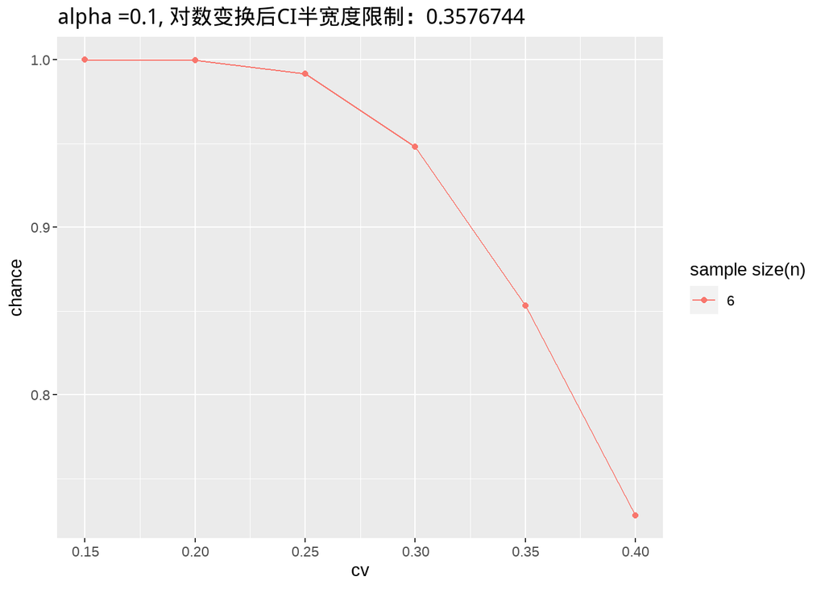

## 0.4 Appendix